# Practical Machine Learning - Final Project

Simona Maccarrone

26 August 2016

# Introduction

Using devices such as Jawbone Up, Nike FuelBand, and Fitbit it is now possible to collect a large amount of data about personal activity relatively inexpensively. These type of devices are part of the quantified self movement, a group of enthusiasts who take measurements about themselves regularly to improve their health, to find patterns in their behavior, or because they are tech geeks. One thing that people regularly do is quantify how much of a particular activity they do, but they rarely quantify how well they do it. In this project, your goal will be to use data from accelerometers on the belt, forearm, arm, and dumbell of 6 participants. They were asked to perform barbell lifts correctly and incorrectly in 5 different ways. More information is available from the website here: http://groupware.les.inf.puc-rio.br/har (see the section on the Weight Lifting Exercise Dataset).

# Data Source

The training data for this project are available here: https://d396qusza40orc.cloudfront.net/predmachlearn/pml-training.csv The test data are available here: https://d396qusza40orc.cloudfront.net/predmachlearn/pml-testing.csv

The data for this project come from this source: http://groupware.les.inf.puc-rio.br/har. If you use the document you create for this class for any purpose please cite them as they have been very generous in allowing their data to be used for this kind of assignment.

# Explore and clean the data

The data were imported with the following code:

```r
training <- read.csv('https://d396qusza40orc.cloudfront.net/predmachlearn/pml-training.csv',
                     na.strings=c("NA","#DIV/0!",""))
testing <- read.csv('https://d396qusza40orc.cloudfront.net/predmachlearn/pml-testing.csv',
                    na.strings=c("NA","#DIV/0!",""))
```

Then I started to explore those I am going to use for the training:

```r
summary(training)
```

[output not shown]

I noticed that a lot of predictors had more than 90% of NAs so I decided to discard them since they won’t contribute in a relevant way:

```r
#selection of the columns with the maximum number of useful observables for both training
#and testing data sets
predictors1 <- colnames(training)[colSums(is.na(training))==0]
predictors2 <- colnames(testing)[colSums(is.na(testing))==0]
#subsets of training and test data only with the the predictors selected above
train_sub <- subset(training, select=predictors1)
test_sub <- subset(testing, select=predictors2)
```

I also deleted the first seven columns since they do not influence the predictions:

```r
train_sub[1:7] <- NULL
test_sub[1:7] <- NULL
```

and in addition shuffled the training data since they were listed according to *user_name* and *classe*:

```r
training_sub <- train_sub[sample(nrow(train_sub)),]
```

# Cross Validation

```r
library(caret) #loading the caret package
set.seed(1000)
inTrain <- createDataPartition(training_sub$classe, p=0.75, list = FALSE) #create a partition
train <- training_sub[inTrain,] # new training set with 75% of the observables
validation <- training_sub[-inTrain,] # validation data set with 25% of the observables
```

```r
dim(train); dim(validation)
```

```
## [1] 14718    53
```

```
## [1] 4904   53
```

# Predictions

## Decision Tree

```r
library(rpart)
model1 <- rpart(classe ~., data=train, method="class")
```

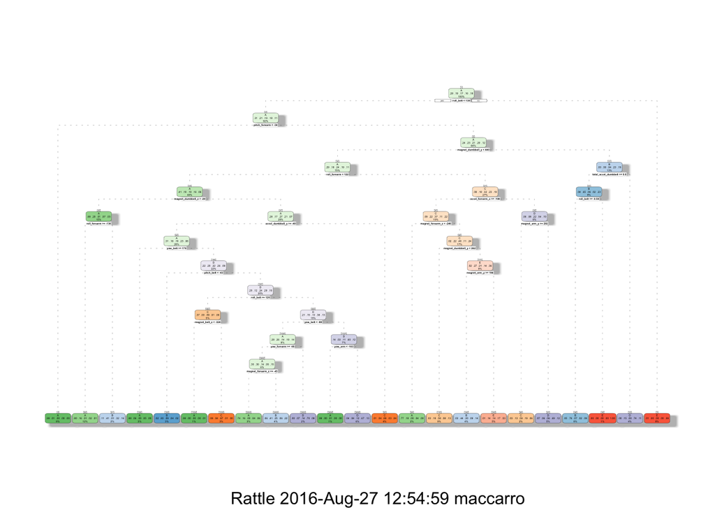

```r
library(rattle)
fancyRpartPlot(model1)
```

```r
#Testing on the evaluation data set
pred_model1 <- predict(model1, validation, type="class")
confusionMatrix(pred_model1, validation$classe)
```

```
## Confusion Matrix and Statistics
##
##           Reference
## Prediction    A    B    C    D    E
##          A 1274  164    9   35   18
##          B   48  578  123   89  114
##          C   38  105  615   70   65
##          D   29   72   82  551  102
##          E    6   30   26   59  602
##
## Overall Statistics
##
##                Accuracy : 0.7382
##                  95% CI : (0.7256, 0.7504)
##     No Information Rate : 0.2845
##     P-Value [Acc > NIR] : < 2.2e-16
##
##                   Kappa : 0.668
##  Mcnemar's Test P-Value : < 2.2e-16
##
## Statistics by Class:
##
##                      Class: A Class: B Class: C Class: D Class: E
## Sensitivity            0.9133   0.6091   0.7193   0.6853   0.6681
## Specificity            0.9356   0.9054   0.9313   0.9305   0.9698
## Pos Pred Value         0.8493   0.6071   0.6887   0.6591   0.8326
## Neg Pred Value         0.9645   0.9061   0.9402   0.9378   0.9285
## Prevalence             0.2845   0.1935   0.1743   0.1639   0.1837
## Detection Rate         0.2598   0.1179   0.1254   0.1124   0.1228
## Detection Prevalence   0.3059   0.1941   0.1821   0.1705   0.1474
## Balanced Accuracy      0.9244   0.7572   0.8253   0.8079   0.8190
```

The accuracy was not so satisfactory.

## Random Forest

I first runned the Random Forest with default parameters and pca as method of preprocessing and I realized it was very very slow. Hence I looked up in internet how to solve the problem.  
First step I used the two logical cores that I have on my laptop as follows:

```r
library(doParallel)
registerDoParallel(cores=2)
```

then I runned the Random Forest limiting the number of trees to 100:

```r
library(randomForest)
model2 <- train(classe~., data=train, method="rf", preProcess="pca", ntree=100,
                do.trace=TRUE)
```

```
## ntree      OOB      1      2      3      4      5
##     1:  22.49% 16.07% 24.59% 28.34% 24.97% 22.11%
##     2:  21.80% 15.01% 25.18% 27.69% 22.58% 22.14%
##     3:  21.13% 14.45% 25.52% 26.82% 21.51% 20.94%
##     4:  20.21% 13.13% 25.02% 26.20% 20.69% 19.96%
##     5:  19.23% 13.09% 24.19% 24.34% 19.30% 18.56%
##     6:  17.84% 12.05% 22.55% 22.93% 17.93% 16.89%
##     7:  16.14% 10.87% 20.45% 20.06% 16.69% 15.59%
##     8:  15.22%  9.87% 20.01% 19.64% 15.68% 13.87%
##     9:  14.27%  9.44% 18.71% 17.33% 15.54% 13.04%
##    10:  13.37%  9.05% 17.08% 16.97% 14.52% 11.74%
##    11:  12.07%  8.10% 14.94% 15.16% 13.07% 11.37%
##    12:  11.04%  7.03% 13.43% 14.24% 12.72% 10.21%
##    13:  10.29%  6.49% 12.97% 12.50% 11.65% 10.04%
##    14:   9.75%  6.15% 12.57% 11.93% 10.93%  9.22%
```

[output cut: 86 more lines]

The OBB was around 3%. Since I was enough satisfied with the results, I moved to test the model on the validation data set:

```r
pred_model2 <- predict(model2, validation, type="raw")
# type="class" was giving me some error message
confusionMatrix(pred_model2, validation$classe)
```

```
## Confusion Matrix and Statistics
##
##           Reference
## Prediction    A    B    C    D    E
##          A 1380   19    2    1    1
##          B    9  915   13    3    5
##          C    3   12  826   33    1
##          D    2    0   14  765    2
##          E    1    3    0    2  892
##
## Overall Statistics
##
##                Accuracy : 0.9743
##                  95% CI : (0.9695, 0.9786)
##     No Information Rate : 0.2845
##     P-Value [Acc > NIR] : < 2e-16
##
##                   Kappa : 0.9675
##  Mcnemar's Test P-Value : 0.09068
##
## Statistics by Class:
##
##                      Class: A Class: B Class: C Class: D Class: E
## Sensitivity            0.9892   0.9642   0.9661   0.9515   0.9900
## Specificity            0.9934   0.9924   0.9879   0.9956   0.9985
## Pos Pred Value         0.9836   0.9683   0.9440   0.9770   0.9933
## Neg Pred Value         0.9957   0.9914   0.9928   0.9905   0.9978
## Prevalence             0.2845   0.1935   0.1743   0.1639   0.1837
## Detection Rate         0.2814   0.1866   0.1684   0.1560   0.1819
## Detection Prevalence   0.2861   0.1927   0.1784   0.1597   0.1831
## Balanced Accuracy      0.9913   0.9783   0.9770   0.9736   0.9943
```

The accuracy was very high.  
N. B. I also tried ntree=200, it was slower and the OBB did not decrease that much.  
I decided then to use this model for predicting the *classe* of the test data set (now *test_sub* after the cleaning process).

```r
# making the prediction for the 20 cases
predfinal_model2 <- predict(model2, test_sub, type="raw")
```

The predictions I got using the model were 95% correct.